# PheWAS with PhenoScanner

Silva Kasela

06/01/2020

Lookup cis-eQTLs related to COVID-19 genes using PhenoScanner v2:

- Using covid19_candidate_genes_v11.txt
- Significant lead cis-eQTLs related to COVID-19 genes (qvalue < 0.05) - 108 gene-variant pairs
- rsIDs to lookup (including also former rsIDs) - 114

## PhenoScanner

> PhenoScanner V2 Cardiovascular Epidemiology Unit University of Cambridge Email: phenoscanner@gmail.com

> Information: Each user can query a maximum of 500 SNPs, 50 genes or 50 regions per hour. For large batch queries, please ask to download the data from www.phenoscanner.medschl.cam.ac.uk/data. Terms of use: Please refer to the terms of use when using PhenoScanner V2 (www.phenoscanner.medschl.cam.ac.uk/about). If you use the results from PhenoScanner in a publication or presentation, please cite all of the relevant references of the data used and the PhenoScanner publications: www.phenoscanner.medschl.cam.ac.uk/about/#citation.
- Note: UKB summary stats are from 2017 - phase 1 results
- Note: PhenoScanner outputs associations with P-value < 1e-05
- Clean results - keep only one entry per gene and trait
  - If both height_GIANT and height_UKB, keep UKB entry
  - Or keep entry from the newest study

#### Summary

- Number eQTLs that have PheWAS associations - **44 eQTLs and 122 phenotypes**
- Categories that have the most associations
  - Some smaller categories merged together

| efo_category_parent | n |
| --- | --- |
| Anthropometric measurement | 142 |
| Hematological measurement | 57 |
| Uncategorised | 48 |
| Other disease/trait | 31 |
| Metabolic disorder/measurement | 13 |
| Pulmonary function measurement | 6 |
| Neurological disorder | 3 |
| Respiratory disease | 3 |
| Immune system disorder | 2 |

- Hematological measurement consists of the following blood cell traits

| trait | efo_category | efo_category_parent | n |
| --- | --- | --- | --- |
| Basophil count | Basophil | Hematological measurement | 1 |
| Eosinophil count | Eosinophil | Hematological measurement | 2 |
| Eosinophil percentage of granulocytes | Eosinophil | Hematological measurement | 2 |
| Eosinophil percentage of white cells | Eosinophil | Hematological measurement | 2 |
| Granulocyte count | Granulocyte | Hematological measurement | 1 |
| Granulocyte percentage of myeloid white cells | Granulocyte | Hematological measurement | 3 |
| Hematocrit | Red cells volume | Hematological measurement | 1 |
| Hemoglobin concentration | Hemoglobin | Hematological measurement | 1 |
| Immature fraction of reticulocytes | Reticulocyte | Hematological measurement | 1 |
| Lymphocyte count | Lymphocyte | Hematological measurement | 1 |
| Lymphocyte percentage of white cells | Lymphocyte | Hematological measurement | 1 |
| Mean corpuscular hemoglobin | Hemoglobin | Hematological measurement | 2 |
| Mean corpuscular hemoglobin concentration | Hemoglobin | Hematological measurement | 1 |
| Mean corpuscular volume | Red cells volume | Hematological measurement | 2 |
| Mean platelet volume | Platelet | Hematological measurement | 2 |
| Monocyte count | Monocyte | Hematological measurement | 3 |
| Monocyte percentage of white cells | Monocyte | Hematological measurement | 5 |
| Myeloid white cell count | White cells | Hematological measurement | 1 |
| Neutrophil count | Neutrophil | Hematological measurement | 1 |
| Neutrophil percentage of granulocytes | Neutrophil | Hematological measurement | 2 |
| Neutrophil percentage of white cells | Neutrophil | Hematological measurement | 2 |
| Platelet count | Platelet | Hematological measurement | 3 |
| Platelet distribution width | Platelet | Hematological measurement | 3 |
| Plateletcrit | Platelet | Hematological measurement | 2 |
| Red blood cell count | Red cells | Hematological measurement | 1 |
| Red cell distribution width | Red cells | Hematological measurement | 3 |
| Sum basophil neutrophil counts | Sum cell counts | Hematological measurement | 1 |
| Sum eosinophil basophil counts | Sum cell counts | Hematological measurement | 3 |
| Sum neutrophil eosinophil counts | Sum cell counts | Hematological measurement | 1 |
| White blood cell count | White cells | Hematological measurement | 3 |

- Number of genes that have eQTLs implicated in 1) blood cell traits, 2) pulmonary function trait, and/or 3) respiratory system disease - **20 genes**

| gene_name | efo_category_parent |
| --- | --- |
| CEP250 | Pulmonary function measurement |
| CTSB | Hematological measurement |
| CTSF | Hematological measurement |
| CTSS | Hematological measurement |
| CTSW | Hematological measurement |
| ERMP1 | Respiratory disease |
| FAR2 | Pulmonary function measurement |
| FOXO1 | Hematological measurement |
| FOXO1 | Respiratory disease |
| HEATR3 | Hematological measurement |
| IDE | Hematological measurement |
| IFITM3 | Hematological measurement |
| MEPCE | Hematological measurement |
| NINL | Hematological measurement |
| PABPC4 | Hematological measurement |
| RAB2A | Hematological measurement |
| SAAL1 | Hematological measurement |
| TBCA | Hematological measurement |
| TLE3 | Pulmonary function measurement |
| TMED5 | Hematological measurement |
| ZYG11B | Hematological measurement |

#### PheWAS plots

Highlighting here some of the more interesting PheWAS asscoaitions with some of the eGenes. See eqtl/cis/phenoscanner/phewas_plot.covid19_related_egenes_v11.pdf for all the PheWAS plots.

- CTSW - weight and some cell types
- IFITM3 - assocated with different cell type traits
- MEPCE - associated with different platelet traits

[output not shown]

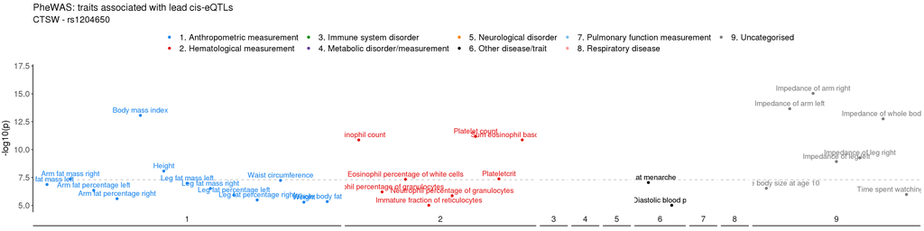

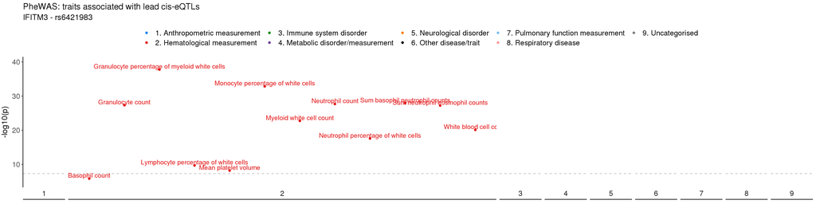

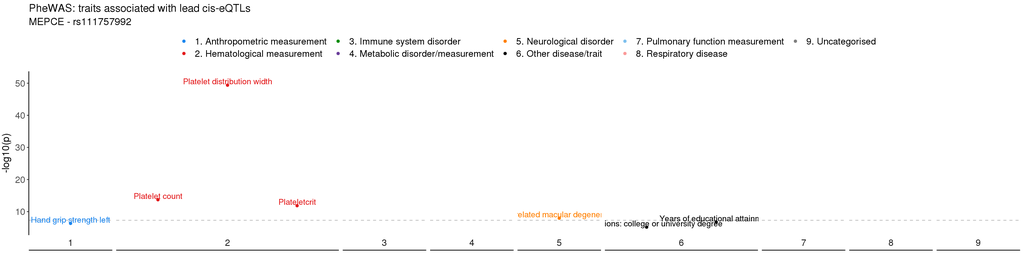

#### PheWAS heatmap

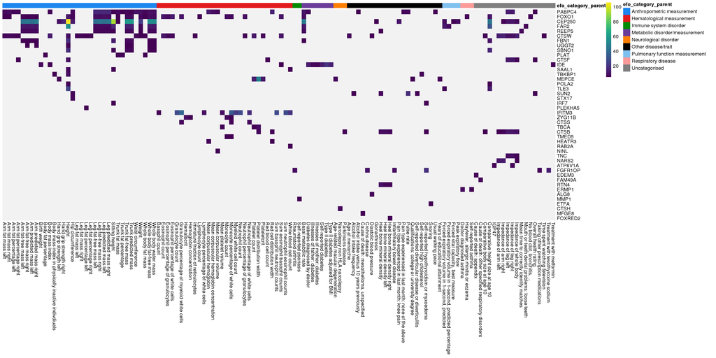

Heatmap including only genes that have >1 association

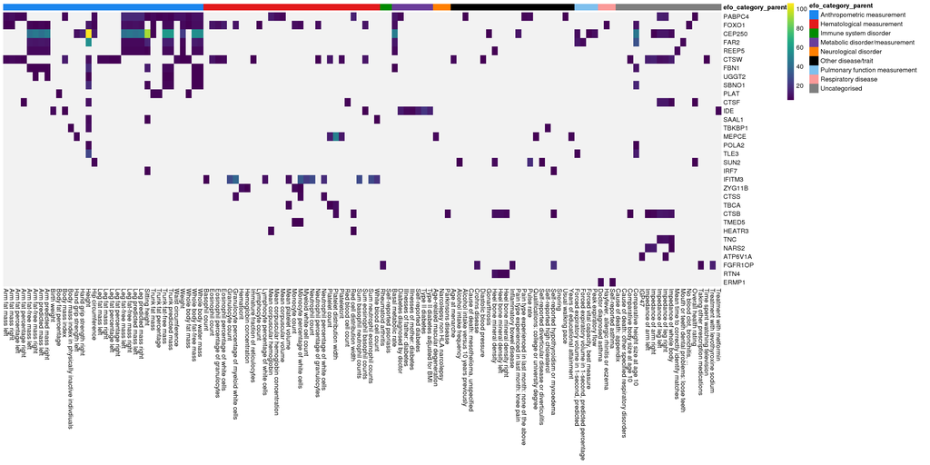